# People I Know: Job Search and Social Networks

Cingano, F., & Rosolia, A. (2012). Journal of Labor Economics. https://doi.org/10.1086/663357

Yu-Hsin Ho

April 2, 2024

# Overview

- Information is essential during job search
  - Market conditions, job opportunities, etc.
- Does insider information facilitates job search? By how much?
  - Knowing someone nears the job opportunity → reduces search costs → shorter unemployment spell

This paper:

- Estimate the causal effect of **network employment rate** on **unemployment duration**
- Mechanism: **information sharing**

We focus on identification strategy and how authors justify their causal interpretation

# Empirical model

Consider a model of network effects on unemployment duration:

$$u_i = \alpha + \gamma ER_{it_0} + \theta \log(N_{it_0}) + X_{it_0} \beta + e_{it_0}$$

- $u_i$: (log) unemployment duration of invidivual $i$
- $ER_{it_0}$: network employment rate at the time of displacement $t_0$

**Baseline definition of network** $W_{it_0}$:

- Coworkers of individual $i$ in $[t_0 - 5, t_0]$ with at least 1 month of overlap
  - Past coworkers network provide more valuable job information than other networks
- Individual-specific: key to the identification strategy

# Identification challenges

$$u_i = \alpha + \gamma ER_{it_0} + \theta \log(N_{it_0}) + X_{it_0} \beta + e_{it_0}$$

Problem: $ER_{it_0}$ is non-random

The relationship between $ER_{it_0}$ and $u_i$ has various sources of endogeneity:

1. Self-select to quit jobs
2. Unobserved worker characteristics
3. Common local labor market shocks
1. Self-select to quit jobs
   - Workers with better $ER_{it_0}$ are more likely to quit and have lower $u_i$
   - Biased sample: only observe workers who *actually* quit
   - **Solution**: exogenous job displacement – firm shutdown
     - Workers in the same shutdown event are dropped from $W_{it_0}$
2. Unobserved worker characteristics
   - High-ability workers have better $ER_{it_0}$ and lower $u_i$
   - **Solution**: (i) closing firm fixed effects; (ii) control for observable employment history
     - Make comparison across workers within the same shutdown firm
       - Absorb unobserved dimensions that appear in sorting behavior
     - Control wage history and tenure, which proxies for ability
3. Common local labor market shocks
   - Worker and her coworkers are subject to common labor market shocks
   - Think about workers’ network in Hsinchu Science Park when TSMC is booming
   - **Solution**: add labor market fixed effects

## Wrap up

1. Exogenous job displacement: Firm shutdown
2. Unobserved worker characteristics:
   1. Closing firm fixed effects: within-closing-firm comparison
   2. Observable individual and network characteristics: wage history, tenure, etc.
   3. **Caveat**: unobservables not revealed through sorting are not controlled (e.g. differential skill accumulation)
3. Local labor demand shocks: local labor market (LLM) fixed effects

# Data

- Employer-employee linked panel from 2 Italian provinces, 1975-1997
  - Demographic: age, gender, place of birth, residence
  - Job & employer information: weekly earnings, tenure, industry, location
  - Taiwanese equivalent: labor insurance data
- Consider only shutdown events in 1980-94
  - 5-year window for network definition
  - 3-year window for unemployment spell completion
    - median = 5 months; mean = 10 months; minimal censoring

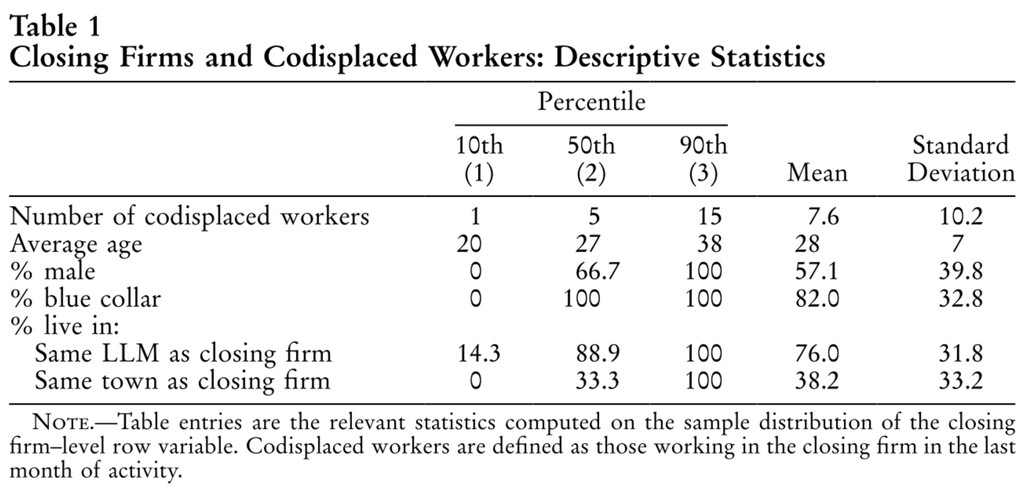

Summary statistics (Cingano and Rosolia 2012, Table 1)

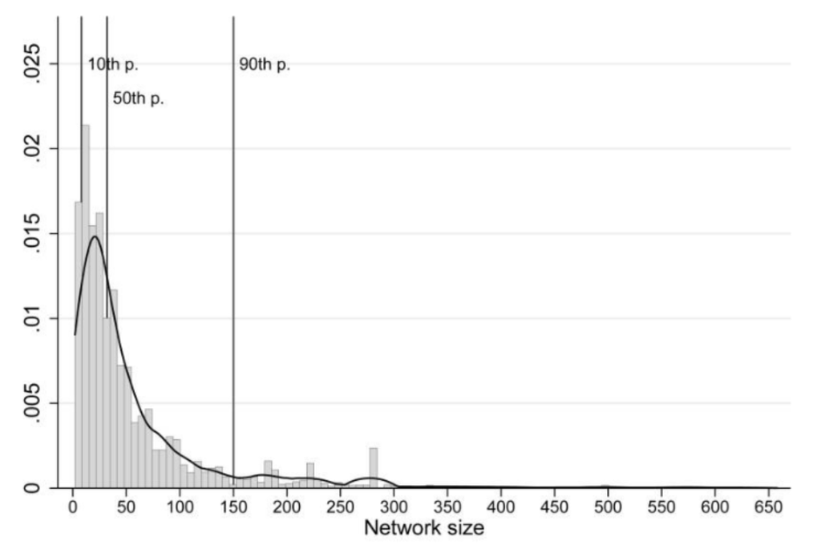

Network size distribution

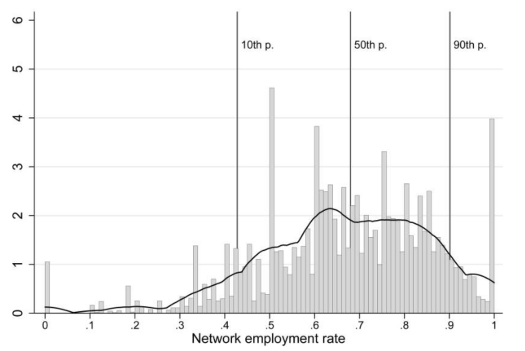

Network employment rate distribution

Figure 1: Network characteristics (Cingano and Rosolia 2012, Figure 1)

# Baseline results

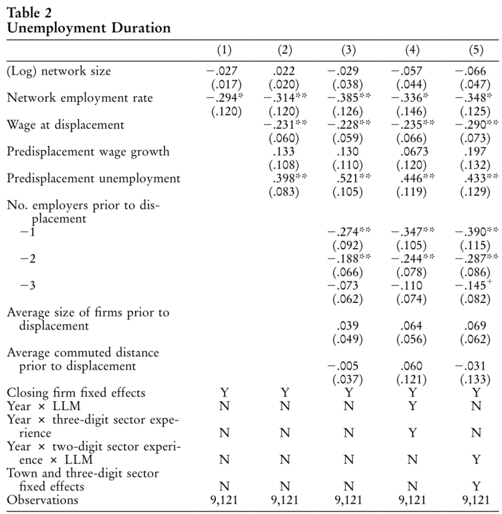

Baseline results (Cingano and Rosolia 2012, Table 2)

LHS: log unemployment duration

Estimated elasticity: -0.3

10 ppt ↑ network employment rate

⇒ 3% ↓ unemployment duration

⇒ (1.2 weeks ↓)

# Interpretation

Network effects ≠ Information sharing effects

1. **Information sharing**: Someone proximated to job opportunities shares those information
   - search costs ↓ ⇒ duration of job search ↓
2. **Peer pressure**: Knowing most of your friends are working, you feel more pressure to find a job
   - reservation wage ↓ ⇒ duration of job search ↓
3. **Expectation**: Knowing most of your friends are working, you think the labor market is booming
   - reservation wage ↑ ⇒ duration of job search ↑

Authors conduct falsification tests to reject (2) and (3)

## Falsification excercises

2. **Peer pressure**:
   1. Use lag network employment rate: if pressure exists, should be a significant predictor
   2. Control for contacts’ ability: if pressure exists, $\hat\gamma$ should become smaller
      - Proxies for contacts’ ability: (i) wage (ii) tenure
3. **Expectation**:
   - Model the expectation on contacts’ employment using a probit model: $\Pr(E_{jt_0}) = \Phi(\text{age, time, location})$
   - Get $\widehat\Pr{E_{jt_0}}$, take average over contacts, and use it as a control variable
   - If expectation matters, $\hat\gamma$ should become smaller

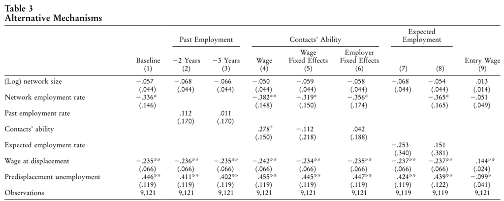

Alternative mechanisms (Cingano and Rosolia 2012, Table 3)

## Information availability

Some contacts are more likely to hold valuable job informations:

- Switch jobs recently
- Work in the same industry / nearby workspace
- Live nearby
- Stronger ties (being coworkers for a longer time)

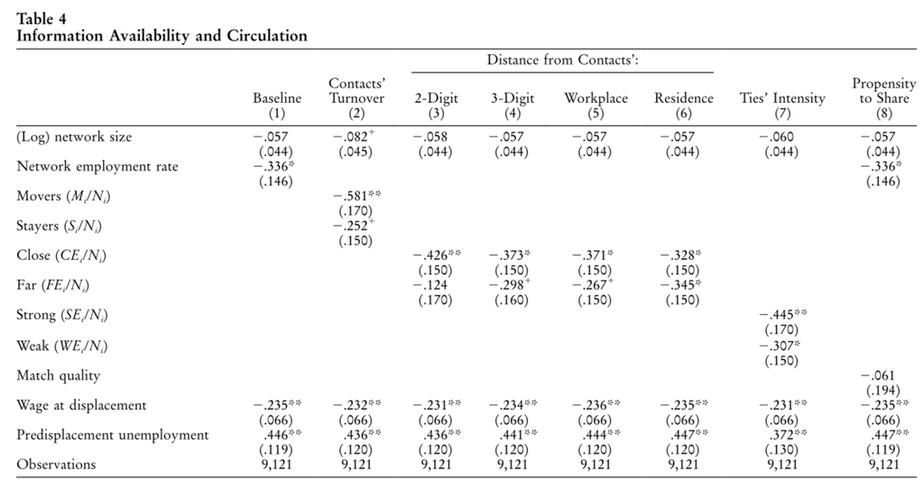

Information availability (Cingano and Rosolia 2012, Table 4)

# Heterogeneity by network composition

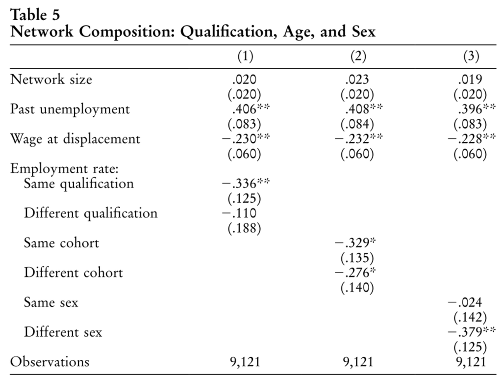

Network composition (Cingano and Rosolia 2012, Table 5)

# Indirect connections

- **Competitor**: Contacts’ contacts may compete with you for the same job
- **Provider**: Contacts’ contacts may help you find a job
- **Diverse contacts** provide less duplicated information

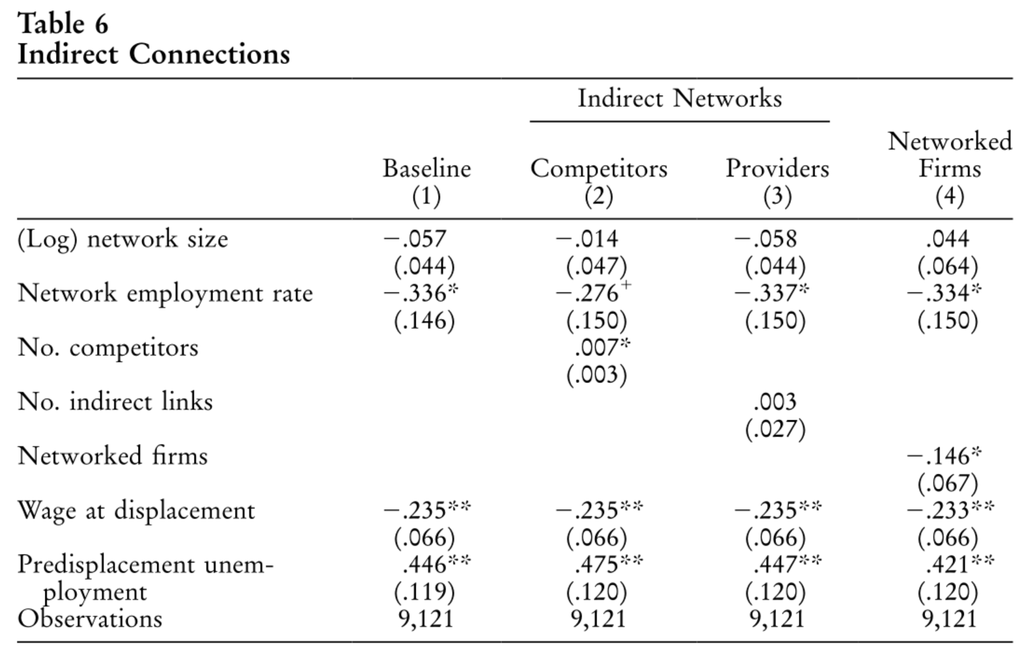

Indirect connections (Cingano and Rosolia 2012, Table 6)

# Takeaways

- **Information sharing** in social networks facilitates job search
  - **Positive spillover** of one’s employment status to network members
- **Identification strategy**:
  - Exogenous job displacement
  - Closing firm fixed effects
  - Observable individual and network characteristics
  - Local labor market fixed effects